# Exploration of Flight Dataset -"Airline On-Time Performance Data"

## Introduction

> The dataset name is "Airline On-Time Performance Data". This dataset reports flights in the United States, including carriers, arrival and departure delays, and reasons for delay, from 1987 to 1989.

The features of interest in the dataset are;

> **Actual Arrival Times (ArrTime):** is the instance when the pilot sets the aircraft parking brake after arriving at the airport gate or passenger unloading area.

> **Actual Departure Times (DepTime):** is the instance when the pilot releases the aircraft parking brake after passengers have loaded and aircraft doors have been closed.

> **Arrival Delay (ArrDelay):** Arrival delay equals the difference of the actual arrival time minus the scheduled arrival time.

> **CRS Computer Reservation System.** CRS provide information on airline schedules, fares and seat availability to travel agencies and allow agents to book seats and issue tickets.

> **Cancelled Flight (Cancelled):** A flight that was listed in a carrier's computer reservation system during the seven calendar days prior to scheduled departure but was not operated.

> **Departure Delay (DepDelay):** The difference between the scheduled departure time and the actual departure time from the origin airport gate.

> **Diverted Flight (Diverted):** A flight that is required to land at a destination other than the original scheduled destination for reasons beyond the control of the pilot/company.

> **Elapsed Time (for CRSElapsedTime & ActualElapsedTIme):** The time computed from gate departure time to gate arrival time.

> **Scheduled Departure Time (CSRSDepTime):** The scheduled time that an aircraft should lift off from the origin airport.

> **Scheduled Time Of Arrival (CRSArrTime):** The scheduled time that an aircraft should cross a certain point (landing or metering fix).

> **Unique Carrier (unique):** Unique Carrier Code. It is the Carrier Code most recently used by a carrier. A numeric suffix is used to distinguish duplicate codes, for example, PA, PA (1), PA (2). Use this field to perform analysis of data reported by one and only one carrier.

## Preliminary Wrangling

```python
# import all packages and set plots to be embedded inline
import numpy as np
import pandas as pd
import matplotlib.pyplot as plt
import seaborn as sb
import zipfile
from zipfile import ZipFile

%matplotlib inline
```

### Loading the datasets

```python
flight_87 = pd.read_csv("1987.csv.bz2")
```

```python
flight_88 = pd.read_csv("1988.csv.bz2")
```

```python
flight_89 = pd.read_csv("1989.csv.bz2")
```

```python
#combining the datasets to form one master dataset
flights_comb = [flight_87, flight_88, flight_89]
flight = pd.concat(flights_comb, ignore_index =True)
```

```python
#checking the shape of the combined dataset and printing the datatype of the various features
print(flight.shape)
print(flight.dtypes)
```

```
(11555122, 29)
Year                   int64
Month                  int64
DayofMonth             int64
DayOfWeek              int64
DepTime              float64
CRSDepTime             int64
ArrTime              float64
CRSArrTime             int64
UniqueCarrier         object
FlightNum              int64
TailNum              float64
ActualElapsedTime    float64
CRSElapsedTime         int64
AirTime              float64
ArrDelay             float64
DepDelay             float64
Origin                object
Dest                  object
Distance             float64
TaxiIn               float64
TaxiOut              float64
Cancelled              int64
CancellationCode     float64
Diverted               int64
CarrierDelay         float64
WeatherDelay         float64
NASDelay             float64
SecurityDelay        float64
LateAircraftDelay    float64
dtype: object
```

```python
#printing some rows of the dataset
flight.head()
```

|  | Year | Month | DayofMonth | DayOfWeek | DepTime | CRSDepTime | ArrTime | CRSArrTime | UniqueCarrier | FlightNum | ... | TaxiIn | TaxiOut | Cancelled | CancellationCode | Diverted | CarrierDelay | WeatherDelay | NASDelay | SecurityDelay | LateAircraftDelay |
| --- | --- | --- | --- | --- | --- | --- | --- | --- | --- | --- | --- | --- | --- | --- | --- | --- | --- | --- | --- | --- | --- |
| 0 | 1987 | 10 | 14 | 3 | 741.0 | 730 | 912.0 | 849 | PS | 1451 | ... | NaN | NaN | 0 | NaN | 0 | NaN | NaN | NaN | NaN | NaN |
| 1 | 1987 | 10 | 15 | 4 | 729.0 | 730 | 903.0 | 849 | PS | 1451 | ... | NaN | NaN | 0 | NaN | 0 | NaN | NaN | NaN | NaN | NaN |
| 2 | 1987 | 10 | 17 | 6 | 741.0 | 730 | 918.0 | 849 | PS | 1451 | ... | NaN | NaN | 0 | NaN | 0 | NaN | NaN | NaN | NaN | NaN |
| 3 | 1987 | 10 | 18 | 7 | 729.0 | 730 | 847.0 | 849 | PS | 1451 | ... | NaN | NaN | 0 | NaN | 0 | NaN | NaN | NaN | NaN | NaN |
| 4 | 1987 | 10 | 19 | 1 | 749.0 | 730 | 922.0 | 849 | PS | 1451 | ... | NaN | NaN | 0 | NaN | 0 | NaN | NaN | NaN | NaN | NaN |

5 rows × 29 columns

```python
#Making copy of the dataset
flights = flight.copy()
```

```python
#Forming a "Date" column with data from the columns "Year, Month and DayOfMonth"
flights["Date"] = pd.to_datetime(dict(year=flights.Year, month=flights.Month, day=flights.DayofMonth))
```

```python
#Dropping irrelevant columns from the dataset
flights = flights.drop(["Year", "Month", "DayofMonth", "TaxiIn", "TaxiOut", "CancellationCode", "TailNum", "FlightNum", "AirTime", "CarrierDelay", "WeatherDelay", "NASDelay", "SecurityDelay", "LateAircraftDelay"], axis=1)
```

```python
#Rearranging the columns so "Date" will appear first
flights.insert(0, "Date", flights.pop("Date"))
```

**The column "DayOfWeek" contains numeric representation of the days of the week;**

> 1 = Monday, 2 = Tuesday, 3 = Wednesday, 4 = Thursday, 5 = Friday, 6 = Saturday, 7 = Sunday.

Therefore, we will convert these numeric values to the actual days of the week

```python
#Converting the column datatype to str in order to be able to replace the values accordingly
flights[["DayOfWeek", "Cancelled", "Diverted"]] = flights[["DayOfWeek", "Cancelled", "Diverted"]].astype(str)
```

```python
#Replacing the numeric values with the days of the week
flights["DayOfWeek"] = flights["DayOfWeek"].replace(["1", "2", "3", "4", "5", "6", "7"], ["Monday", "Tuesday", "Wednesday", "Thursday", "Friday", "Saturday", "Sunday"])
flights["Cancelled"] = flights["Cancelled"].replace(["0", "1"], ["No", "Yes"])
flights["Diverted"] = flights["Diverted"].replace(["0", "1"], ["No", "Yes"])
```

```python
#getting information about the features
flights.info()
```

```
<class 'pandas.core.frame.DataFrame'>
RangeIndex: 11555122 entries, 0 to 11555121
Data columns (total 16 columns):
Date                 datetime64[ns]
DayOfWeek            object
DepTime              float64
CRSDepTime           int64
ArrTime              float64
CRSArrTime           int64
UniqueCarrier        object
ActualElapsedTime    float64
CRSElapsedTime       int64
ArrDelay             float64
DepDelay             float64
Origin               object
Dest                 object
Distance             float64
Cancelled            object
Diverted             object
dtypes: datetime64[ns](1), float64(6), int64(3), object(6)
memory usage: 1.4+ GB
```

```python
#Checking for Null cells
flights.isnull().sum()
```

```
Date                      0
DayOfWeek                 0
DepTime              144013
CRSDepTime                0
ArrTime              177103
CRSArrTime                0
UniqueCarrier             0
ActualElapsedTime    177103
CRSElapsedTime            0
ArrDelay             177103
DepDelay             144013
Origin                    0
Dest                      0
Distance              39105
Cancelled                 0
Diverted                  0
dtype: int64
```

```python
#Converting columns with datatype "float" to datatype "int" and replacing Null cells with zero (0)
flights[["DepTime", "ArrTime", "ActualElapsedTime", "ArrDelay", "DepDelay", "Distance"]] = flights[["DepTime", "ArrTime", "ActualElapsedTime", "ArrDelay", "DepDelay", "Distance"]].fillna(0).astype(int)
```

```python
#checking for comformity
flights.info()
```

```
<class 'pandas.core.frame.DataFrame'>
RangeIndex: 11555122 entries, 0 to 11555121
Data columns (total 16 columns):
Date                 datetime64[ns]
DayOfWeek            object
DepTime              int64
CRSDepTime           int64
ArrTime              int64
CRSArrTime           int64
UniqueCarrier        object
ActualElapsedTime    int64
CRSElapsedTime       int64
ArrDelay             int64
DepDelay             int64
Origin               object
Dest                 object
Distance             int64
Cancelled            object
Diverted             object
dtypes: datetime64[ns](1), int64(9), object(6)
memory usage: 1.4+ GB
```

```python
#Checking the shape of the dataset
flights.shape
```

```
(11555122, 16)
```

### Converting Various Columns into datetime datatype and arranging their format appropriately

```python
L = list(flights["DepTime"])
get_time1 = lambda time: str(time)[:-2] + ':' + str(time)[-2:]
flights["DepTime"] = list(map(get_time1,L))
```

```python
M = list(flights["CRSDepTime"])
get_time2 = lambda time: str(time)[:-2] + ':' + str(time)[-2:]
flights["CRSDepTime"] = list(map(get_time2,M))
```

```python
N = list(flights["ArrTime"])
get_time3 = lambda time: str(time)[:-2] + ':' + str(time)[-2:]
flights["ArrTime"] = list(map(get_time3,N))
```

```python
O = list(flights["CRSArrTime"])
get_time4 = lambda time: str(time)[:-2] + ':' + str(time)[-2:]
flights["CRSArrTime"] = list(map(get_time4,O))
```

```python
#printing some rows to check for comformity
flights.head()
```

|  | Date | DayOfWeek | DepTime | CRSDepTime | ArrTime | CRSArrTime | UniqueCarrier | ActualElapsedTime | CRSElapsedTime | ArrDelay | DepDelay | Origin | Dest | Distance | Cancelled | Diverted |
| --- | --- | --- | --- | --- | --- | --- | --- | --- | --- | --- | --- | --- | --- | --- | --- | --- |
| 0 | 1987-10-14 | Wednesday | 7:41 | 7:30 | 9:12 | 8:49 | PS | 91 | 79 | 23 | 11 | SAN | SFO | 447 | No | No |
| 1 | 1987-10-15 | Thursday | 7:29 | 7:30 | 9:03 | 8:49 | PS | 94 | 79 | 14 | -1 | SAN | SFO | 447 | No | No |
| 2 | 1987-10-17 | Saturday | 7:41 | 7:30 | 9:18 | 8:49 | PS | 97 | 79 | 29 | 11 | SAN | SFO | 447 | No | No |
| 3 | 1987-10-18 | Sunday | 7:29 | 7:30 | 8:47 | 8:49 | PS | 78 | 79 | -2 | -1 | SAN | SFO | 447 | No | No |
| 4 | 1987-10-19 | Monday | 7:49 | 7:30 | 9:22 | 8:49 | PS | 93 | 79 | 33 | 19 | SAN | SFO | 447 | No | No |

```python
#forming a dataframe of flight data for year 1987 alone
start_date = "1987-10-1"
end_date = "1987-12-31"
mask = (flights["Date"] > start_date) & (flights["Date"] <= end_date)
df1 = flights.loc[mask]
```

```python
#forming a dataframe of flight data for year 1988 alone
start_date = "1988-1-1"
end_date = "1988-12-31"
mask = (flights["Date"] > start_date) & (flights["Date"] <= end_date)
df2 = flights.loc[mask]
```

```python
#forming a dataframe of flight data for year 1989 alone
start_date = "1989-1-1"
end_date = "1989-12-31"
mask = (flights["Date"] > start_date) & (flights["Date"] <= end_date)
df3 = flights.loc[mask]
```

### What features in the dataset do you think will help support your investigation into your feature(s) of interest?

> From the features of interest, as stated above, we will be much concerned with the features; Cancelled, Diverted, Dest, Origin, ArrDelay, DepDelay, DepTime, ArrTime. The other colummns(variables) in the wrangled dataset will support, though to a lesser proportion.

## Univariate Exploration

### Question:

> How many flights were cancelled for the year 1987, 1988, and 1989 respectively and what are their percentage proportion.

### Wrangling:

#### Seperating the dataset by year

```python
#getting the unique value count of the feature "Cancelled" fot the various year (i.e 1987, 1988, 1989)
df1_plot = df1["Cancelled"].value_counts()
df2_plot = df2["Cancelled"].value_counts()
df3_plot = df3["Cancelled"].value_counts()

#getting the sum of the unique value counts
df1_vc = df1_plot.sum()
df2_vc = df2_plot.sum()
df3_vc = df3_plot.sum()
```

```python
df1_plot
```

```
No     1277528
Yes      19532
Name: Cancelled, dtype: int64
```

```python
df2_plot
```

```
No     5139252
Yes      50037
Name: Cancelled, dtype: int64
```

```python
df3_plot
```

```
No     4953995
Yes      73779
Name: Cancelled, dtype: int64
```

### Visualizations:

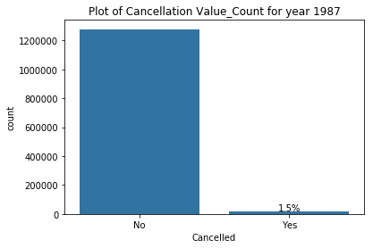

```python
base_color = sb.color_palette()[0]

#plotting a bar chart of value counts for the feature "Cancelled" for the year 1987, indicating the percentage proportion of the bar
sb.countplot(data = df1, x = "Cancelled", color = base_color)
type_counts = df1_plot
locs, labels = plt.xticks(rotation = 360)
for loc, label in zip(locs, labels):
    count = type_counts[label.get_text()]
    pct_string = "{:.2}%".format(100*count/df1_vc)

plt.text(loc, count+1, pct_string, ha = "center", color = "black")
plt.title("Plot of Cancellation Value_Count for year 1987");
```

*The chart shows us that there was a 1.5% flight cancellation during the year 1987*

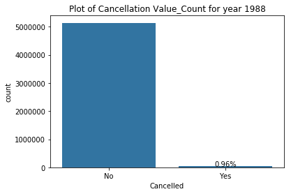

```python
#plotting a bar chart of value counts for the feature "Cancelled" for the year 1988, indicating the percentage proportion of the bar
sb.countplot(data = df2, x = "Cancelled", color = base_color)
type_counts = df2_plot
locs, labels = plt.xticks(rotation = 360)
for loc, label in zip(locs, labels):
    count = type_counts[label.get_text()]
    pct_string = "{:.2}%".format(100*count/df2_vc)

plt.text(loc, count+1, pct_string, ha = "center", color = "black")
plt.title("Plot of Cancellation Value_Count for year 1988");
```

*The chart shows us that there was a 0.96% flight cancellation during the year of 1988*

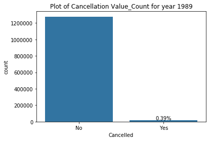

```python
#plotting a bar chart of value counts for the feature "Cancelled" for the year 1989, indicating the percentage proportion of the bar
sb.countplot(data = df1, x = "Cancelled", color = base_color)
type_counts = df1_plot
locs, labels = plt.xticks(rotation = 360)
for loc, label in zip(locs, labels):
    count = type_counts[label.get_text()]
    pct_string = "{:.2}%".format(100*count/df3_vc)

plt.text(loc, count+1, pct_string, ha = "center", color = "black")
plt.title("Plot of Cancellation Value_Count for year 1989");
```

### Question:

> What is the frequency of flight for each unique Origin and Destinstion

### Visualization:

```python
#programatically calculating the value count of "origin" 1987
origin1_plot = df1["Origin"].value_counts()
```

```python
dest1_plot = df1["Dest"].value_counts()
```

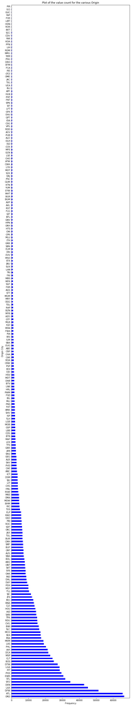

```python
#bar plot of flight origin unique value counts for year 1987
origin1_plot.plot(kind = "barh", color = "blue", figsize = (10,60))
plt.title("Plot of the value count for the various Origin")
plt.xlabel("Frequency")
plt.ylabel("Origin City");
```

> *In year 1987, the top five cities with the highest number of flights originating from them are (in descending order);* **ORD, ATL, DFW, LAX, DEN** *while* **PIR, ILG, GUC, YAP, FOE** *have the lowest number of flights going out from them.*

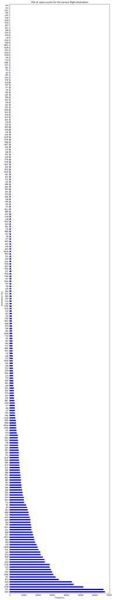

```python
#bar plot of flight destination unique value_counts for year 1987
dest1_plot.plot(kind = "barh", color = "blue", figsize = (10,60))
plt.title("Plot of value counts for the various flight destination")
plt.xlabel("Frequency")
plt.ylabel("Destination City");
```

> *In year 1987, the top five cities with the highest number of flights arriving at them, are (in descending order);* **ORD, ATL, DFW, LAX, DEN** *while* **PIH, ILG, GUC, YAP, FOE** *have the lowest number of flights arriving at them.*

```python
#programatically calculating the value count of "origin" 1988
origin2_plot = df2["Origin"].value_counts()
```

```python
dest2_plot = df2["Dest"].value_counts()
```

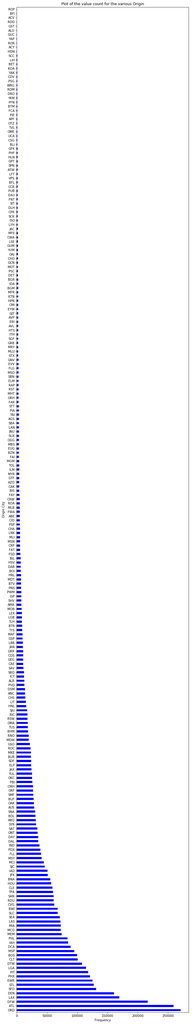

```python
#plotting a bar chart to visualize this value count for year 1988
origin2_plot.plot(kind = "barh", color = "blue", figsize = (10,60));
plt.title("Plot of the value count for the various Origin")
plt.xlabel("Frequency")
plt.ylabel("Origin City");
```

> *In year 1988, the top five cities with the highest number of originating from them, are (in descending order);* **ORD, ATL, DFW, LAX, DEN** *while* **ROP, BFI, ACO, RDD, GST** *have the lowest number of flights originating from them.*

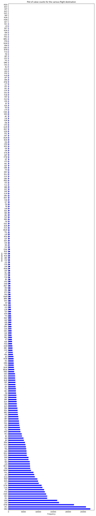

```python
#bar plot of flight destination unique value_counts for year 1988
dest2_plot.plot(kind = "barh", color = "blue", figsize = (10,60))
plt.title("Plot of value counts for the various flight destination")
plt.xlabel("Frequency")
plt.ylabel("Destination");
```

```python
#programatically calculating the value count of "origin" 1989
origin3_plot = df3["Origin"].value_counts()
```

```python
dest3_plot = df3["Dest"].value_counts()
```

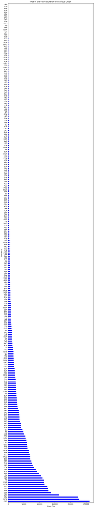

```python
#bar plot of flight origin unique value_counts for year 1989
origin3_plot.plot(kind = "barh", color = "blue", figsize = (10,60));
plt.title("Plot of the value count for the various Origin")
plt.xlabel("Origin City")
plt.ylabel("Frequency");
```

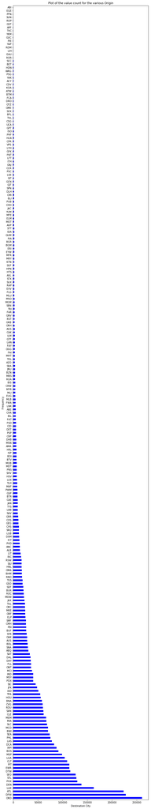

```python
#bar plot of flight destination unique value_counts for year 1989
origin3_plot.plot(kind = "barh", color = "blue", figsize = (10,60));
plt.title("Plot of the value count for the various Origin")
plt.xlabel("Destination City")
plt.ylabel("Frequency");
```

### Observations:

> For the feature "Origin", the investigation shows that the origin(Cities): ORD, ATL, DFW, LAX, DEN have the highest frequency of flights going out of them and this trend is the same for the three years under consideration (i.e 1987, 1988, 1989).

> For the feature "Dest", which represents the destination cities, the same cities ORD, ATL, DFW, LAX and DEN have the highest frequency of flights arrival, and this trend is the same for the years under consideration (1987, 1988, 1989).

### Discuss the distribution(s) of your variable(s) of interest. Were there any unusual points? Did you need to perform any transformations?

> The feature "Cancelled" was represented with numbers (0 and 1) which does not easily tell us if the flight was cancelled or not.

### Of the features you investigated, were there any unusual distributions? Did you perform any operations on the data to tidy, adjust, or change the form of the data? If so, why did you do this?

> When investigating the "Cancelled" feature for the three years under consideration (1987, 1988, 1989), a number of issues was observed. Firstly, the corresponding value for Cancellation were given as 0 and 1, representing No and Yes. Also, when the Null (NAN or NA) data were dropped, it actually removed all the rows in which there was a flight cancellation (i.e Cancellation is Yes).

Therefore, to solve this issues, 0 and 1 were replaced with "No" and "Yes" respectively. Dropping of the Null cells was suspended since the feature "Cancelled" is among the main features of investigation.

## Bivariate Exploration

### Question:

> Are there certain "Destination" or arrival cities that are home to more delays or cancellations?

> Is this trend also observed in subsequent years?

> When is the best day of week to fly inorder to minimize delays and cancellation?

### Initial Wrangling

#### Locating rows that shows Cancelled = yes

```python
#locating the rows for year 1987 dataset
des1 = df1["Cancelled"] == "Yes"
dest1 = df1.loc[des1]
```

```python
#locating the rows for year 1988 dataset
des2 = df2["Cancelled"] == "Yes"
dest2 = df2.loc[des2]
```

```python
#locating the rows for year 1989 dataset
des3 = df3["Cancelled"] == "Yes"
dest3 = df3.loc[des3]
```

```python
#setting up parameters for plotting
new_plot = dest1["Dest"].value_counts()
```

```python
#showing the new parameter to ensure comformity
new_plot
```

```
ORD    1696
DEN    1371
ATL    1046
LAX     783
SFO     650
STL     636
DCA     439
DFW     432
LGA     430
DTW     429
BOS     422
EWR     361
PHX     361
MSP     346
IAH     251
SLC     236
BWI     234
MIA     228
SAN     227
MCI     219
CLT     217
PHL     216
PIT     212
LAS     202
MEM     200
IAD     200
SEA     200
SJC     188
OKC     165
CLE     163
       ...
GUM       4
VPS       4
FCA       4
MLB       4
SBN       4
ACV       4
ISO       3
EVV       3
EAU       3
OAJ       3
YKM       3
CDV       3
YAK       3
PSG       3
SCC       2
PFN       2
GPT       2
HDN       2
MFE       2
GFK       2
ILG       2
PUB       2
FNT       2
RDD       2
PHF       2
HLN       2
GUC       1
OME       1
ROR       1
OTZ       1
Name: Dest, Length: 230, dtype: int64
```

```python
#setting up parameters for plotting
new_plot2 = dest2["Dest"].value_counts()
new_plot2
```

```
ORD    4249
ATL    3031
EWR    1674
BOS    1624
LGA    1611
MSP    1488
DTW    1481
DEN    1408
DFW    1379
STL    1300
DCA    1191
LAX    1051
SFO    1038
PIT     986
CLT     971
PHL     922
MEM     868
RDU     635
MIA     606
PHX     601
IAH     598
BWI     598
SEA     578
IAD     563
CLE     518
MCI     422
JFK     422
MCO     414
CVG     403
TPA     402
       ...
FNT      12
BFL      12
STX      12
GFK      12
MFE      11
RDM      11
BET      11
PUB      11
OME      10
YAK      10
YKM       9
PSC       8
ALO       8
YUM       7
HLN       7
HDN       7
CPR       7
PHF       6
FCA       6
APF       6
GUC       4
LIH       4
KOA       4
PIE       4
PFN       4
ROR       2
YAP       1
ACY       1
GST       1
CDV       1
Name: Dest, Length: 233, dtype: int64
```

```python
#checking up parameter for plotting
new_plot3 = dest3["Dest"].value_counts()
new_plot3
```

```
ATL    6346
ORD    5429
LGA    2432
DFW    2344
CLT    2159
EWR    2040
LAX    1935
DCA    1825
PIT    1731
BOS    1702
SFO    1628
STL    1619
DTW    1611
MIA    1543
PHL    1385
BWI    1362
RDU    1343
DEN    1211
MSP    1075
TPA    1002
SEA     914
MCO     851
IAH     840
IAD     794
PHX     784
HOU     747
CLE     660
JFK     651
CHS     594
FLL     590
       ...
BTM      15
PIE      14
EAU      12
RDM      12
BFL      12
PUB      11
FNT      11
MGM      11
MLU      10
ATW      10
BGR       9
ACY       9
GJT       9
HLN       8
GUC       7
YKM       6
CDV       6
FCA       6
KOA       5
GPT       5
CSG       5
YUM       5
VPS       5
YAP       4
SUN       3
CPR       2
LIH       2
DRO       1
APF       1
TVC       1
Name: Dest, Length: 232, dtype: int64
```

### Visualizations:

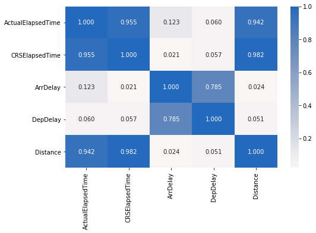

```python
#correlation plot
plt.figure(figsize = [8, 5])
sb.heatmap(flights.corr(), annot = True, fmt = '.3f', cmap = 'vlag_r', center = 0)
plt.show()
```

> *From the heatmap showing the correlation between the various features of the dataset, its seen that Arrival Delay and Departure Delay have a positive correlation*

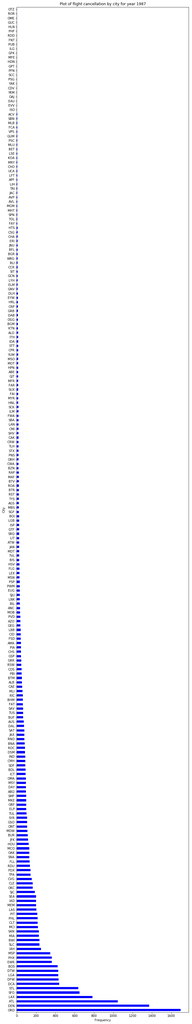

```python
#bar plot of flight cancellation by city for year 1987
new_plot.plot(kind = "barh", color = "blue", figsize =(10,60))
plt.title("Plot of flight cancellation by city for year 1987")
plt.xlabel("Frequency")
plt.ylabel("City");
```

> *For year 1987, the top five cities with the highest number of cancellations are;* **ORD(1,696), DEN(1,371), ATL(1,046), LAX(783), SFO(650)**

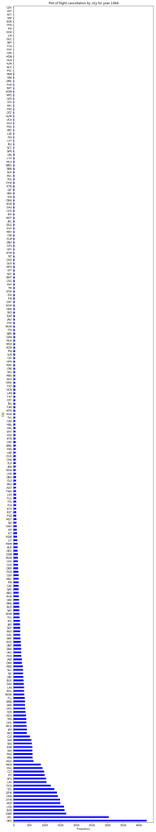

```python
#plot of flight cancellation by city for year 1988
new_plot2.plot(kind = "barh", color = "blue", figsize =(10,60))
plt.title("Plot of flight cancellation by city for year 1988")
plt.xlabel("Frequency")
plt.ylabel("City");
```

> *For year 1988, the top five cities with the highest number of cancellations are;* **ORD(4,249), ATL(3,031), EWR(1,674), BOS(1,624), LGA(1,611)**

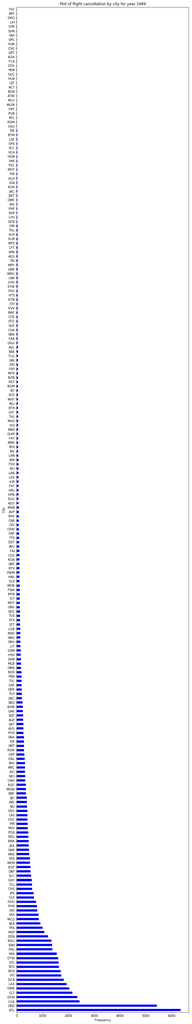

```python
#bar plot of flight cancellation by city for year 1989
new_plot3.plot(kind = "barh", color = "blue", figsize =(10,60))
plt.title("Plot of flight cancellation by city for year 1989")
plt.xlabel("Frequency")
plt.ylabel("City");
```

> *For year 1989, the top five cities with the highest number of cancellations are;* **ATL(6,346), ORD(5,429), LGA(2,432), DFW(2,344), CLT(2,159)**

```python
#checking for comformity
flights.head()
```

|  | Date | DayOfWeek | DepTime | CRSDepTime | ArrTime | CRSArrTime | UniqueCarrier | ActualElapsedTime | CRSElapsedTime | ArrDelay | DepDelay | Origin | Dest | Distance | Cancelled | Diverted |
| --- | --- | --- | --- | --- | --- | --- | --- | --- | --- | --- | --- | --- | --- | --- | --- | --- |
| 0 | 1987-10-14 | Wednesday | 7:41 | 7:30 | 9:12 | 8:49 | PS | 91 | 79 | 23 | 11 | SAN | SFO | 447 | No | No |
| 1 | 1987-10-15 | Thursday | 7:29 | 7:30 | 9:03 | 8:49 | PS | 94 | 79 | 14 | -1 | SAN | SFO | 447 | No | No |
| 2 | 1987-10-17 | Saturday | 7:41 | 7:30 | 9:18 | 8:49 | PS | 97 | 79 | 29 | 11 | SAN | SFO | 447 | No | No |
| 3 | 1987-10-18 | Sunday | 7:29 | 7:30 | 8:47 | 8:49 | PS | 78 | 79 | -2 | -1 | SAN | SFO | 447 | No | No |
| 4 | 1987-10-19 | Monday | 7:49 | 7:30 | 9:22 | 8:49 | PS | 93 | 79 | 33 | 19 | SAN | SFO | 447 | No | No |

```python
#using unique variable to represent the columns for the various datasets
cancl1 = df1["Cancelled"]
cancl2 = df2["Cancelled"]
cancl3 = df3["Cancelled"]

dest1 = df1["Dest"]
dest2 = df2["Dest"]
dest3 = df3["Dest"]

dist1 = df1["Distance"]
dist2 = df2["Distance"]
dist3 = df3["Distance"]

ArrD1 = df1["ArrDelay"]
ArrD2 = df2["ArrDelay"]
ArrD3 = df3["ArrDelay"]

DepD1 = df1["DepDelay"]
DepD2 = df2["DepDelay"]
DepD3 = df3["DepDelay"]

uniq1 = df1["UniqueCarrier"]
uniq2 = df2["UniqueCarrier"]
uniq3 = df3["UniqueCarrier"]

ActElap1 = df1["ActualElapsedTime"]
ActElap2 = df2["ActualElapsedTime"]
ActElap3 = df3["ActualElapsedTime"]

CRSElap1 = df1["CRSElapsedTime"]
CRSElap2 = df2["CRSElapsedTime"]
CRSElap3 = df3["CRSElapsedTime"]

DayOfWeek1 = df1["DayOfWeek"]
DayOfWeek2 = df2["DayOfWeek"]
DayOfWeek3 = df3["DayOfWeek"]
```

```python
#using unique variables to represent various features in the master dataset
canc = flights["Cancelled"]
dest = flights["Dest"]
dist = flights["Distance"]
ArrD = flights["ArrDelay"]
DepD = flights["DepDelay"]
uniq = flights["UniqueCarrier"]
ActElap = flights["ActualElapsedTime"]
CRSElap = flights["CRSElapsedTime"]
DayOfWeek = flights["DayOfWeek"]
Diverted = flights["Diverted"]
```

```python
#function for violin plot for bivariate visualization

def my_func(a, b, c):
    plt.figure(figsize = [15, 6])
    base_color = sb.color_palette()[0]
    plot = sb.violinplot(data = a, x = b , y = c, color = base_color)
```

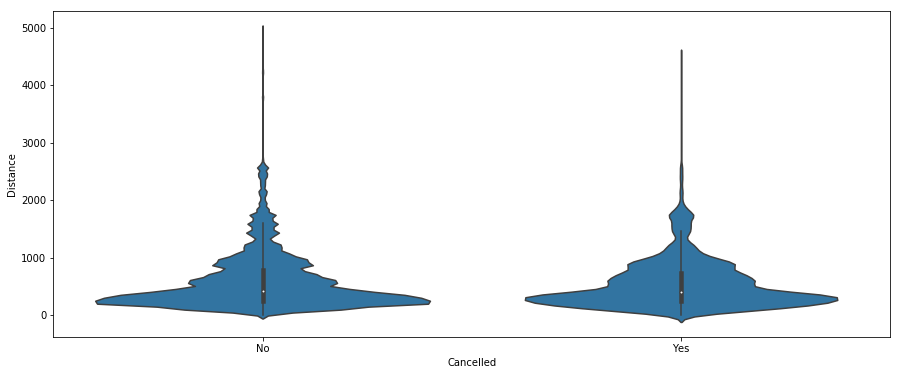

```python
#violin plot showing the distribution of the feature "Cancelled" over "Distance" for year 1987
my_func(df1, cancl1, dist1)
```

> *From the violin plot, for year 1987,it can be seen that No-cancellation occurs most for distances between 0 miles to 1000 miles and cancellations also occurs most within 0 miles and 1000 miles.*

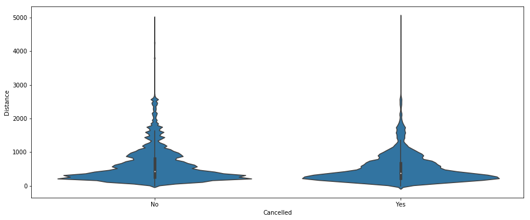

```python
#violin plot showing the distribution of the feature "Cancelled" over "Distance" for year 1988
my_func(df2, cancl2, dist2)
```

> *For year 1988, No-cancellation occurs most for distance within 0 - 1000 miles, and cancellation also occurs within distances 0-1000 miles*

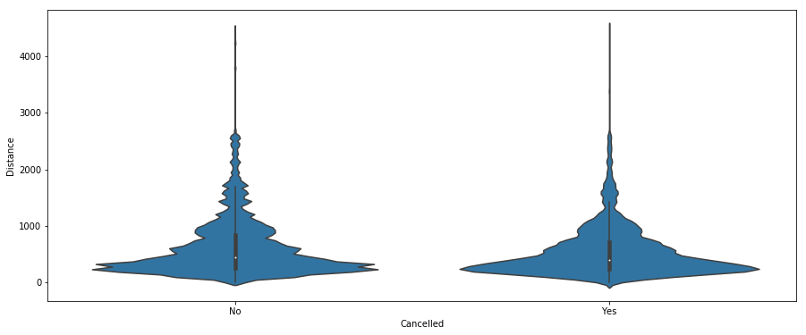

```python
#violin plot showing the distribution of the feature "Cancelled" over "Distance" for year 1987
my_func(df3, cancl3, dist3)
```

> *For year 1989, No-cancellation occurs most within distances of 0-1500 miles, while cancellation occurs most for distances within 0-1100 miles*

```python
#func for scatter plots
def my_func2(a, b, c):
    plt.scatter(data = a, x = b, y = c, alpha = 1/20)
```

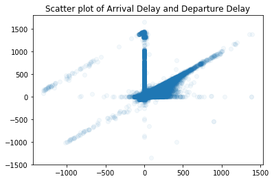

```python
#calliing the function for visualization of "ArrD" and "DepD"
my_func2(flights, ArrD, DepD)
plt.title("Scatter plot of Arrival Delay and Departure Delay");
```

> *The plot shows a positive correlation between Arrival Delay(ArrDelay) and Departure Delay(DepDelay)*

```
Text(0.5,1,'Scatterplot of Actual Elapsed time(ActElap) and CRS Elapsed time(CRSElap)')
```

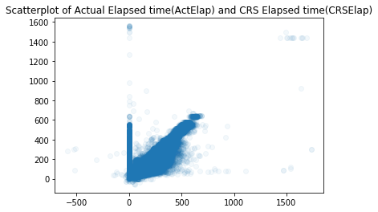

```python
#calling the function for visualization of "ActElap" and "CRSElap"
my_func2(flights, ActElap, CRSElap);
plt.title("Scatterplot of Actual Elapsed time(ActElap) and CRS Elapsed time(CRSElap)")
```

> *As expected, there is a postive correlation between Actual Elapsed time and the CRS Elapsed time. The points are concentrated within 0-500 mins of Actual Elapsed time and 0-600 mins of CRS Elapsed time.*

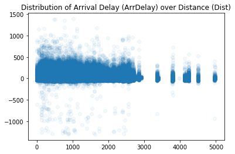

```python
#calling the function for visualization of "dist" and "ArrD"
my_func2(flights, dist, ArrD)
plt.title("Distribution of Arrival Delay (ArrDelay) over Distance (Dist)");
```

> *The points are concentrated parallel along the x-axis (Distance) indicating no correlation between the two features (distance and Arrival delay).*

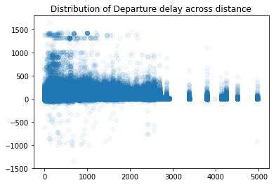

```python
#calling the function for visualization of "dist" and "DepD"
my_func2(flights, dist, DepD)
plt.title("Distribution of Departure delay across distance");
```

> *The points are concentrated paralle along the x-axis (Distance) indicating no correlation between the two features (distance and Departure delay).*

```python
#creating a function for another specification of violin plot
def my_func3(a, b, c):
    plt.figure(figsize = [15, 6])
    base_color = sb.color_palette()[0]
    sb.violinplot(data = a, x = b, y = c, color = base_color)
    plt.xticks(rotation = 90)
```

```python
#converting columns from "object" to "category" datatype
day_of_week = ["Monday", "Tuesday", "Wednesday", "Thursday", "Friday", "Saturday", "Sunday"]
day_classes = pd.api.types.CategoricalDtype(ordered = True, categories = day_of_week)

#using pandas.astype() to convert the "DayOfWeek" columns from a plain object type into an ordered categorical type
DayOfWeek1 = DayOfWeek1.astype(day_classes)
DayOfWeek2 = DayOfWeek2.astype(day_classes)
DayOfWeek3 = DayOfWeek3.astype(day_classes);
```

### Talk about some of the relationships you observed in this part of the investigation. How did the feature(s) of interest vary with other features in the dataset?

> There was an interesting relationship observed between departure delay (DepDelay) and arrival delay (ArrDelay). The correlation is a positive correlation, in the sense that each of the delay increases as the other increases, and vice versa.

### Did you observe any interesting relationships between the other features (not the main feature(s) of interest)?

> A rather interesting observation was made on the relationship between the distance and delay (both ArrDelay and DepDelay). Distance does not have any correlation with either of the delays, whether positive or negative correlation. Therefore, it can be seen that delay is independent of distance of flight.

## Multivariate Exploration

#### Question:

```python
#converting the column datatype to the type "category"
uniq1 = uniq1.astype("category")
cancl1 = cancl1.astype("category")
```

```python
#plotting a multivariate scatterplot of "DepD1", "ArrD1" and "DayOfWeek1"
def my_func4(a, b, c, d):
    fig = plt.figure(figsize = [30,10])
    ax = sb.pointplot(data = a, x = b, y = c, hue = d, palette = "Blues", linestyles = "", dodge = 200)
    ax.set_xticks([-1000, -500, 200, 400, 600, 800])
    ax.set_xticklabels(["-1000", "-500", "200", "400", "600", "800"])
```

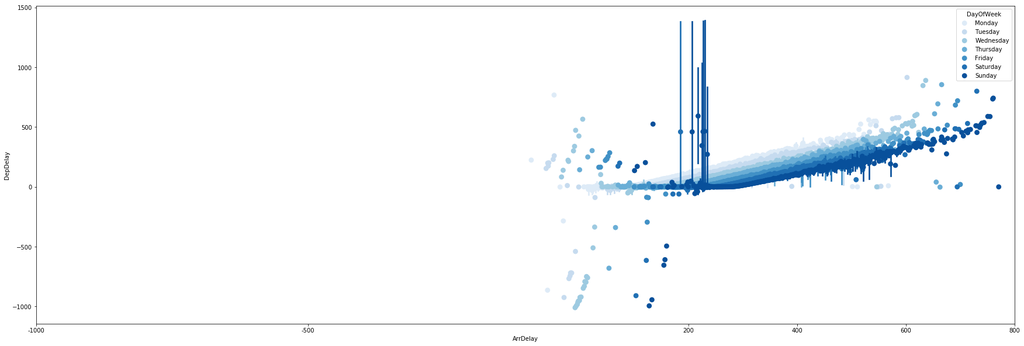

```python
#plotting a point plot of Arrival delay (ArrD1), Departure delay (DepD1) over the Days of Week (DayOfWeek1) for year 1987
my_func4(df1, ArrD1, DepD1, DayOfWeek1);
```

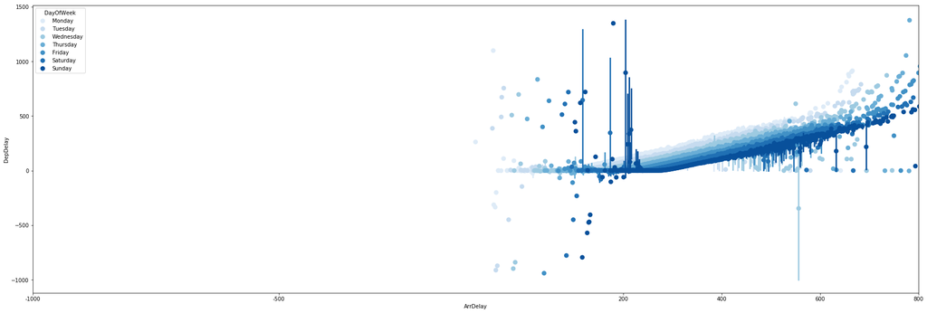

```python
my_func4(df2, ArrD2, DepD2, DayOfWeek2);
```

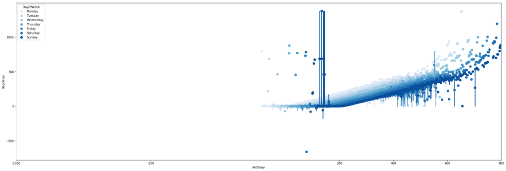

```python
my_func4(df3, ArrD3, DepD3, DayOfWeek3);
```

```python
#plotting a multivariate scatterplot of "DepD1", "ArrD1" and "unique_carrier (uniq)"
def my_func5(a, b, c, d):
    fig = plt.figure(figsize = [30,10])
    ax = sb.pointplot(data = a, x = b, y = c, hue = d, palette = "Blues", linestyles = "", dodge = 0.4)
```

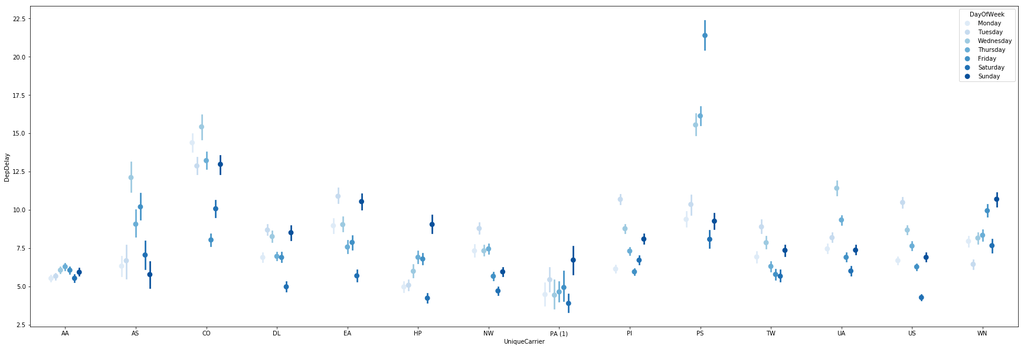

```python
my_func5(df1, uniq1, DepD1, DayOfWeek1);
```

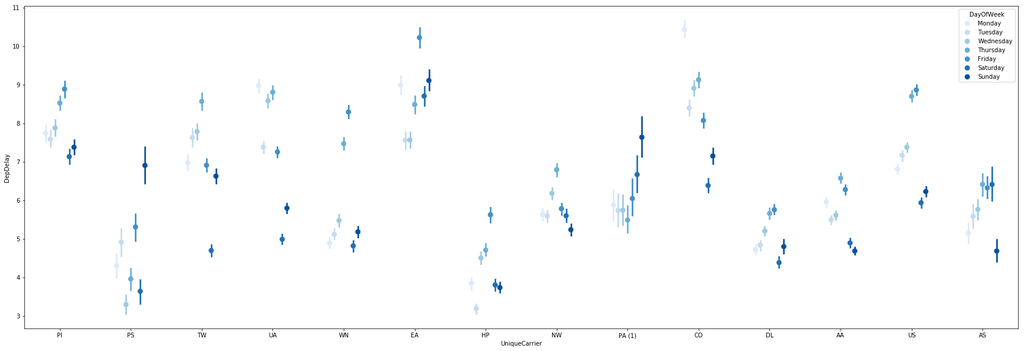

```python
my_func5(df2, uniq2, DepD2, DayOfWeek2)
```

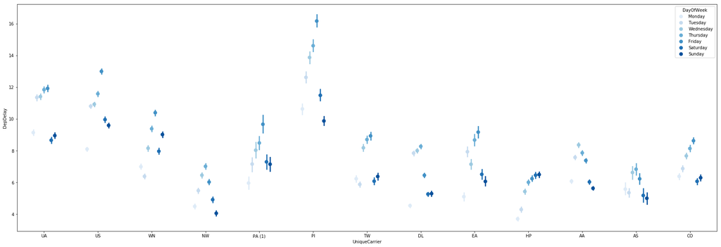

```python
my_func5(df3, uniq3, DepD3, DayOfWeek3)
```

## Conclusions

From the exploration the folowing conclussions are reached;

> For the feature "Origin", the investigation shows that the origin(Cities): ORD, ATL, DFW, LAX, DEN have the highest frequency of flights going out of them and this trend is the same for the three years under consideration (i.e 1987, 1988, 1989).

> For the feature "Dest", which represents the destination cities, the same cities ORD, ATL, DFW, LAX and DEN have the highest frequency of flights arrival, and this trend is the same for the years under consideration (1987, 1988, 1989).